# Milestone Report

Xinyu Li

2017-07-25

## Loading & Summaries

For the purpose of creating a predictive input model, we have been supplied with a dataset https://d396qusza40orc.cloudfront.net/dsscapstone/dataset/Coursera-SwiftKey.zip, containing twitter, news and blog data for 4 languages.

For this part we’ll be solely focussing on the English corpus.

```r
enTwitterLines <- readLines("data/final/en_US/en_US.twitter.txt")
enBlogLines <- readLines("data/final/en_US/en_US.blogs.txt")
enNewsLines <- readLines("data/final/en_US/en_US.news.txt")

wordCount <- function(lns){
  sum(sapply(gregexpr("\\S+", lns), length))
}

meanSentenceLength <- function(lns){
  mean(sapply(gregexpr("\\S+", lns), length))
}

lineCount <- function(lns){
  length(lns)
}

tRow <- c(lineCount(enTwitterLines), wordCount(enTwitterLines), meanSentenceLength(enTwitterLines))
bRow <- c(lineCount(enBlogLines), wordCount(enBlogLines), meanSentenceLength(enBlogLines))
nRow <- c(lineCount(enNewsLines), wordCount(enNewsLines), meanSentenceLength(enNewsLines))

infoEn <- rbind(tRow, bRow, nRow)
rownames(infoEn) <- c("twitter", "blog", "news")
colnames(infoEn) <- c("lines", "words", "mean.words.per.line")

infoEn
```

```
##           lines    words mean.words.per.line
## twitter 2360148 30373543            12.86934
## blog     899288 37334131            41.51521
## news      77259  2643969            34.22215
```

## Sampling

There are ways to calculate the needed sample size, but they don’t reaaly seem to apply to this problem, however.

If we just take 5% of all datasets we still end up with 5M words to be analyzed

*Check the utils package to see how sampling is done randomly*

```r
source("utils.R")
set.seed(11081979)

recreate <- FALSE
sampleFactor <- 0.05
info <- createAllSamples("data/final", sampleFactor, recreate)

twitterENInfo <- sampleFile("data/final/en_US/en_US.twitter.txt")
newsENInfo <- sampleFile("data/final/en_US/en_US.news.txt")
blogsENInfo <- sampleFile("data/final/en_US/en_US.blogs.txt")
```

These info objects contain the sample data & some meta information for later purposes

```r
str(twitterENInfo)
```

```
## List of 8
##  $ sample.data          : chr [1:353757] "I'm doing it!é¦æ" "Looking for a new band to blog for the month. anyone interested?" "Tables are all sold out for the Mystique Masquerade Ball." "I know, I know. Then you kick yourself when the fight goes lopsided. But if the upset DOES happen, wow. Nothi…
##  $ org.lines.length     : int [1:2360148] 109 111 40 84 63 77 101 51 54 30 ...
##  $ org.lines.summary    :Classes 'summaryDefault', 'table'  Named num [1:6] 2 37 64 68.8 100 213
##   .. ..- attr(*, "names")= chr [1:6] "Min." "1st Qu." "Median" "Mean" ...
##  $ org.lines.count      : int 2360148
##  $ org.file.path        : chr "data/final/en_US/en_US.twitter.txt"
##  $ sample.file.path     : chr "data/sample/en_US/en_US.twitter.sample.txt"
##  $ sample.meta.file.path: chr "data/sample/en_US/en_US.twitter.sample.txt.meta"
##  $ locale               : chr "en_US"
```

## Preprocessing

### 1. Tokenization

To actually parse the word’s we are going to use a **whitespace tokenizer**. First we’ll split each line into sentences, because the end of a sentence should probably not be a predictor for the next one. This way we’ll keep tokization independant of context. Then we’ll remove all non word chars, lowercase and split on whitespace. In the end we’ll have a vector of term vectors

```r
tokenize <- function(dataset){
  dataset <- unlist(strsplit(dataset, "[\\.\\,!\\?\\:]+"))
  dataset <- tolower(dataset)
  dataset <- gsub("[^a-z\\s]", " ", dataset)
  dataset <- gsub("\\s+", " ", dataset)
  dataset <- trimws(dataset)
  dataset <- strsplit(dataset, "\\s")
  return(dataset)
}
```

```r
twitterSampleENTokenized <- tokenize(twitterENInfo$sample.data)
newsSampleENTokenized <- tokenize(newsENInfo$sample.data)
blogSampleENTokenized <- tokenize(blogsENInfo$sample.data)
```

### 2. Merging

Since in essence the data is now uniformly for the EN corpus, we should combine these into one dataset

```r
sampleENTokenized <- c(twitterSampleENTokenized, newsSampleENTokenized, blogSampleENTokenized)
```

### 3. Filtering

Next remove some profanity we don’t want in our dataset (we should never suggest profanity)

For each language we’ve downloaded a publicly kept profanity list from https://github.com/LDNOOBW/List-of-Dirty-Naughty-Obscene-and-Otherwise-Bad-Words

```r
profanityFilter <- function(termList, locale){
  profanities <- readLines(paste0("data/config/",locale,"/profanity.txt"))
  lapply(termList, setdiff, y=profanities)
}
```

```r
sampleENTokenized <- profanityFilter(sampleENTokenized, twitterENInfo$locale)
```

We could use to filter other terms, like stopwords or 1 or 2 letter words, but although they probably will not be good predictors themselves (like: the, and, or) they will probably follow some other terms and could be predicted. Stripping them out will alter the syntacticle structure to much and therefore having a major effect on the predictions.

## Explore

### 1. View data

Now we have a sample tokenize dataset. Let’s explore

```r
head(sampleENTokenized, 3)
```

[output not shown]

```r
#Num lines
length(sampleENTokenized)
```

```
## [1] 1517052
```

```r
#Num terms
sum(sapply(sampleENTokenized, length))
```

```
## [1] 9988834
```

### 2. Term frequencies

Using the frequencyTable function we can see what are the most common words in our dataset

```r
frequencyTable <- function(termList){
  term <- data.frame(unlist(termList))
  grouped <- as.data.frame(table(term))
  freq <- grouped[order(-grouped$Freq),]
  rownames(freq) <- 1:nrow(freq)

  total <- sum(freq$Freq)
  freq$CumFreq <- cumsum(freq$Freq)
  freq$Coverage <- freq$CumFreq/total

  return(freq)
}
```

```r
sampleENTermFrequency <- frequencyTable(sampleENTokenized)

head(sampleENTermFrequency, 15)
```

```
##    term   Freq CumFreq   Coverage
## 1   the 339442  339442 0.03398214
## 2    to 247521  586963 0.05876191
## 3   and 212886  799849 0.08007431
## 4     a 211858 1011707 0.10128379
## 5     i 204283 1215990 0.12173493
## 6    of 170568 1386558 0.13881080
## 7    in 143294 1529852 0.15315621
## 8   you 117516 1647368 0.16492095
## 9    is 115919 1763287 0.17652581
## 10  for 111080 1874367 0.18764623
## 11   it 106396 1980763 0.19829772
## 12 that 102107 2082870 0.20851983
## 13   on  82601 2165471 0.21678917
## 14   my  79523 2244994 0.22475036
## 15 with  69509 2314503 0.23170903
```

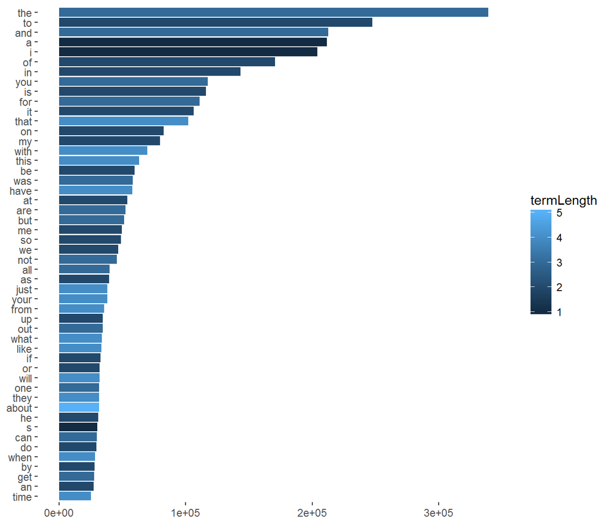

### 3. Check sample

These top terms seem a logical set.

To make sure we can compare our frequencies with a general dataset that collects this information, to see how examplary our sample is for the real word. We downloaded the dataset http://www.wordfrequency.info/top5000.asp

```r
realENWordFrequency <- read.csv("data/config/en_US/word-frequency.csv")
realENWords <- tolower(as.character(unname(realENWordFrequency$Word)))

topLimit <- length(realENWords)

sampleENTermsSlice <- as.character(sampleENTermFrequency$term)[1:topLimit]

#Number of same top frequency words in
numIntersect <- length(intersect(realENWords,sampleENTermsSlice))
numIntersect
```

```
## [1] 2790
```

```r
# Coverage factor
numIntersect/topLimit
```

```
## [1] 0.558
```

### 4. Create n-grams

Now we have term vectors and we are reasonably sure about the quality, we can now create n-grams using this function:

```r
createNgram <- function(vec, n=2){
  l <- length(vec)
  if(l < n){
    return(c())
  }else if(l == n){
    return(paste(vec, collapse = " "))
  }else{
    numNgrams <- l-n+1
    mtrx <- matrix(nrow=numNgrams, ncol=n)
    for(i in 1:n){
      m <- l - n + i
      mtrx[,i] <- vec[i:m]
    }
    ngrams <- apply(mtrx, 1, paste, collapse=" ")
    return(ngrams)
  }
}

transformNGram <- function(termList, n=2){
  lapply(termList, createNgram, n=n)
}
```

### 5. Bi-gram

```r
sampleENBiGrams <- transformNGram(sampleENTokenized, 2)

sampleENBiGramsFrequency <- frequencyTable(sampleENBiGrams)

head(sampleENBiGramsFrequency, 15)
```

```
##       term  Freq CumFreq    Coverage
## 1   in the 25150   25150 0.002943331
## 2   of the 17785   42935 0.005024729
## 3  for the 16356   59291 0.006938889
## 4    to be 15845   75136 0.008793246
## 5   on the 13864   89000 0.010415765
## 6   to the 13009  102009 0.011938222
## 7   i have 10496  112505 0.013166580
## 8     is a  9971  122476 0.014333496
## 9   it was  9799  132275 0.015480284
## 10  at the  9763  142038 0.016622858
## 11    i am  9287  151325 0.017709726
## 12  if you  9221  160546 0.018788869
## 13   it is  9009  169555 0.019843202
## 14    in a  8805  178360 0.020873660
## 15   i was  8648  187008 0.021885745
```

### 6. Tri-gram

```r
sampleENTriGrams <- transformNGram(sampleENTokenized, 3)

sampleENTriGramsFrequency <- frequencyTable(sampleENTriGrams)

head(sampleENTriGramsFrequency, 15)
```

[output not shown]

### 7. Coverage overview

```r
coverageFactor <- function(freqTable, coverage){
  pos <- nrow(freqTable[freqTable$Coverage < coverage,])
  pos / nrow(freqTable)
}
```

Let’s see what the coverage of the n-gram sets is compare to the entire corpus

```r
coverageFactors <- c(0.1,0.5,0.9)
uniCov <- sapply(coverageFactors, coverageFactor, freqTable=sampleENTermFrequency)
biCov <- sapply(coverageFactors, coverageFactor, freqTable=sampleENBiGramsFrequency)
triCov <- sapply(coverageFactors, coverageFactor, freqTable=sampleENTriGramsFrequency)

infoCov <- rbind(uniCov, biCov, triCov)
rownames(infoCov) <- c("uni-gram", "bi-gram", "tri-gram")
colnames(infoCov) <- coverageFactors

infoCov
```

```
##                   0.1          0.5        0.9
## uni-gram 1.707961e-05 0.0007856622 0.03779719
## bi-gram  9.278268e-05 0.0129283204 0.61514330
## tri-gram 1.509802e-03 0.2424583275 0.84849167
```

# Evaluation

## 1. Prediction

We see that small parts of the data are responsible for the bulk of the corpus. This allows prediction to be a smaller model to just focus on the most important parts.

## 2. Next steps

- Reevaluate approach and see if sample size adjust,inclusion of stopwords, punctuation, numbers, etc improve prediction
- Building a predictive model using the identified tokens
- Wrapping up the results and the developed model as a data product, shiny app.